# Lesson 4

### Scatterplots and Perceived Audience Size

Notes:

### Scatterplots

Notes:

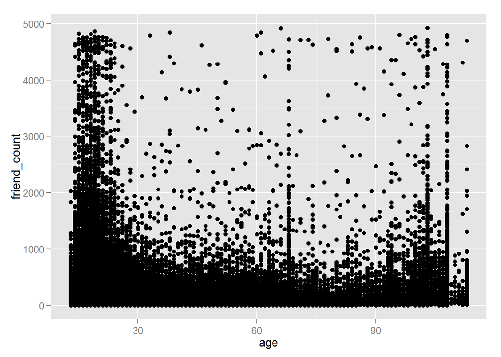

```r
library(ggplot2)
pf <- read.csv("../lesson3/pseudo_facebook.tsv", sep = "\t")

ggplot(pf, aes(x = age, y = friend_count)) +
    geom_point()
```

#### What are some things that you notice right away?

Response:

- Most high values are concentrated in the 18-28 age range
- there are some unusually high values in the >90 age range

### ggplot Syntax

Notes:

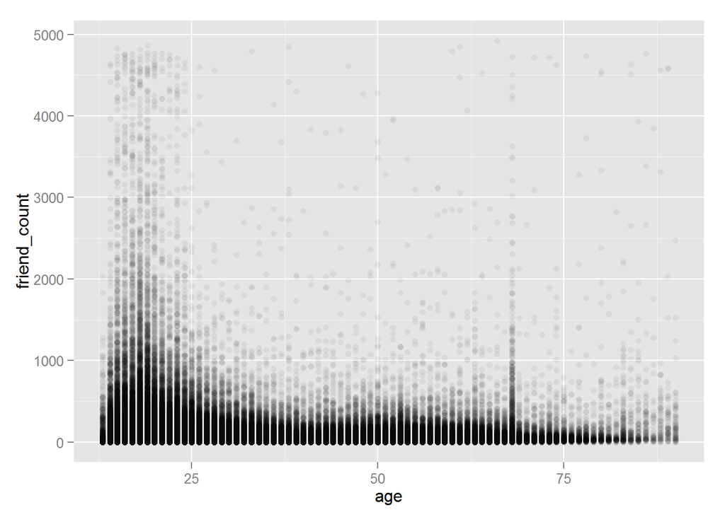

```r
ggplot(pf, aes(x = age, y = friend_count)) +
    geom_point(alpha = 1/20) +
    xlim(13, 90)
```

### Overplotting

Notes:

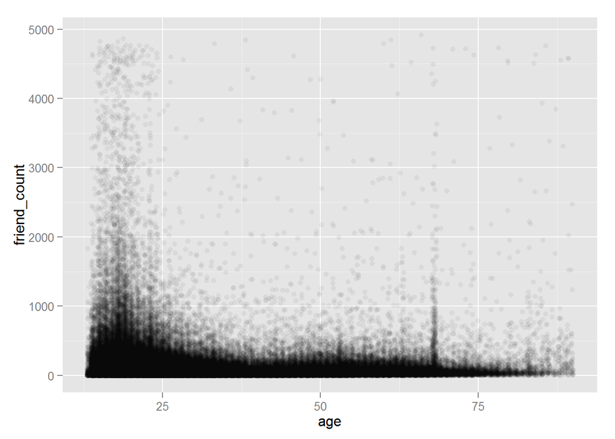

```r
ggplot(pf, aes(x = age, y = friend_count)) +
    geom_jitter(alpha = 1/20) +
    xlim(13, 90)
```

#### What do you notice in the plot?

Response:

We can more easily see where the bulk of the data is located and how the friend count is dependent of the age.

### Coord_trans()

Notes:

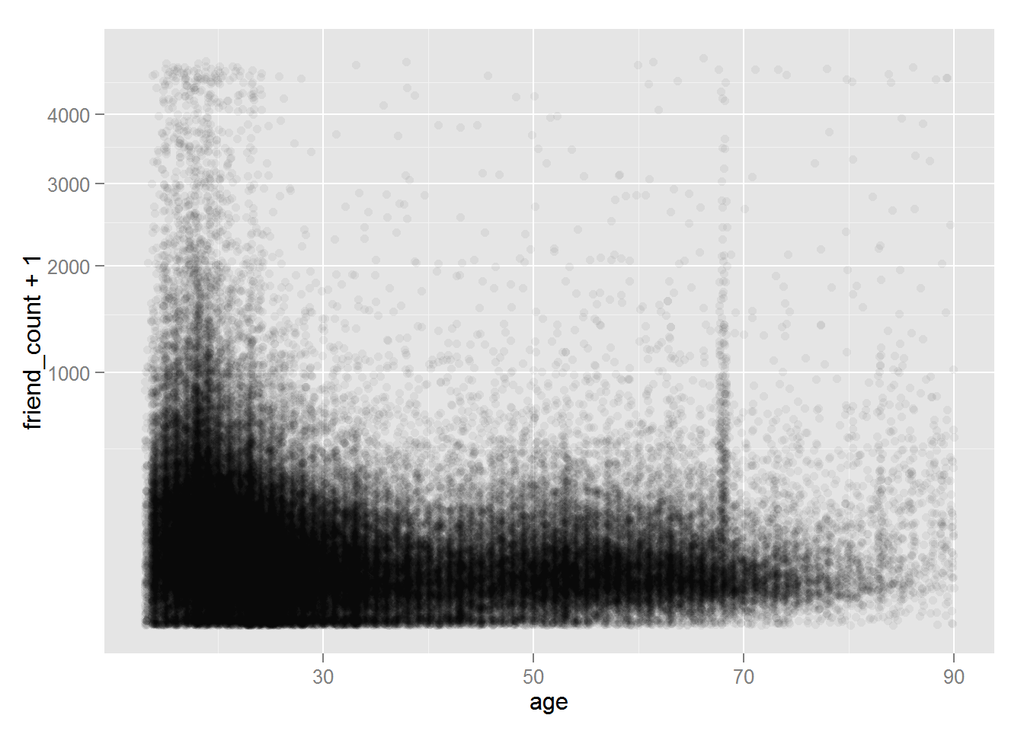

```r
ggplot(pf, aes(x = age, y = friend_count + 1)) +
    geom_jitter(alpha = 1/20) +
    xlim(13, 90) +
    coord_trans(y = "sqrt")
```

#### Look up the documentation for coord_trans() and add a layer to the plot that transforms friend_count using the square root function. Create your plot!

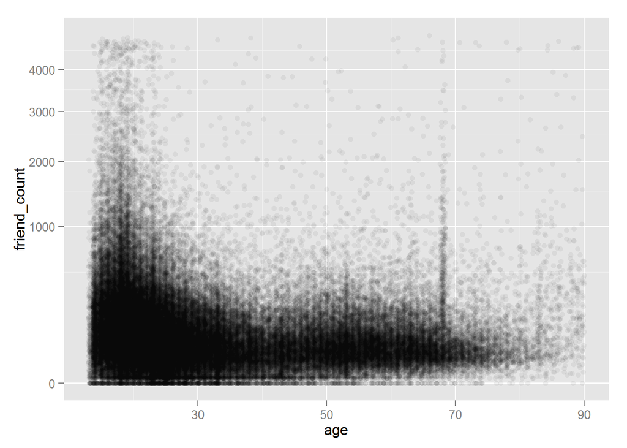

```r
ggplot(pf, aes(x = age, y = friend_count)) +
    geom_point(alpha = 1/20, position = position_jitter(h = 0)) +
    xlim(13, 90) +
    coord_trans(y = "sqrt")
```

#### What do you notice?

In the previous plots the points seemed to be very close to the Ox line because to the scales. Now we see that especially for the middle age group, there is a gap between y= 0 and the mean.

### Alpha and Jitter

Notes:

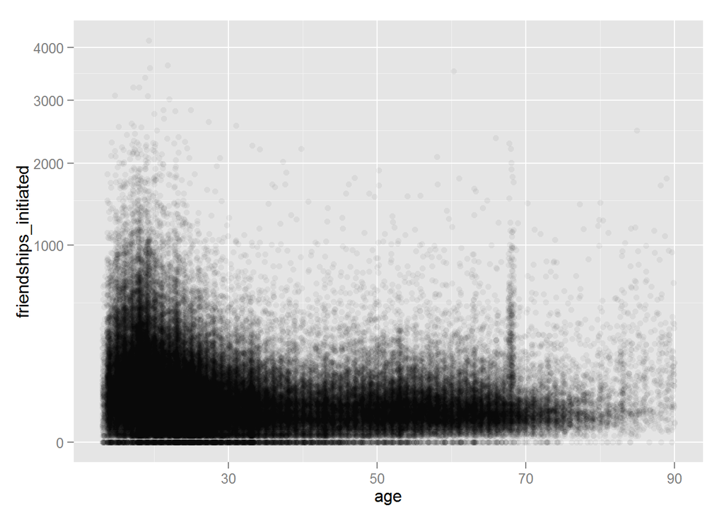

```r
ggplot(pf, aes(x = age, y = friendships_initiated)) +
    geom_point(alpha = 1/20, position = position_jitter(h = 0)) +
    xlim(13, 90) +
    coord_trans(y = "sqrt")
```

### Overplotting and Domain Knowledge

Notes:

### Conditional Means

Notes:

```r
library(dplyr)
pf.fc_by_age <- pf %>%
    group_by(age) %>%
    summarise(friend_count_mean = mean(friend_count),
              friend_count_median = median(friend_count) * 1.0,
              n = n()) %>%
    arrange(age)

pf.fc_by_age
```

```
## Source: local data frame [101 x 4]
##
##    age friend_count_mean friend_count_median    n
## 1   13          164.7500                74.0  484
## 2   14          251.3901               132.0 1925
## 3   15          347.6921               161.0 2618
## 4   16          351.9371               171.5 3086
## 5   17          350.3006               156.0 3283
## 6   18          331.1663               162.0 5196
## 7   19          333.6921               157.0 4391
## 8   20          283.4991               135.0 3769
## 9   21          235.9412               121.0 3671
## 10  22          211.3948               106.0 3032
## .. ...               ...                 ...  ...
```

Create your plot!

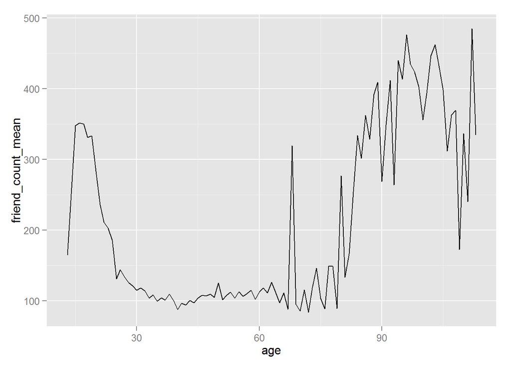

```r
ggplot(pf.fc_by_age, aes(x = age, y = friend_count_mean)) + geom_line()
```

### Overlaying Summaries with Raw Data

Notes:

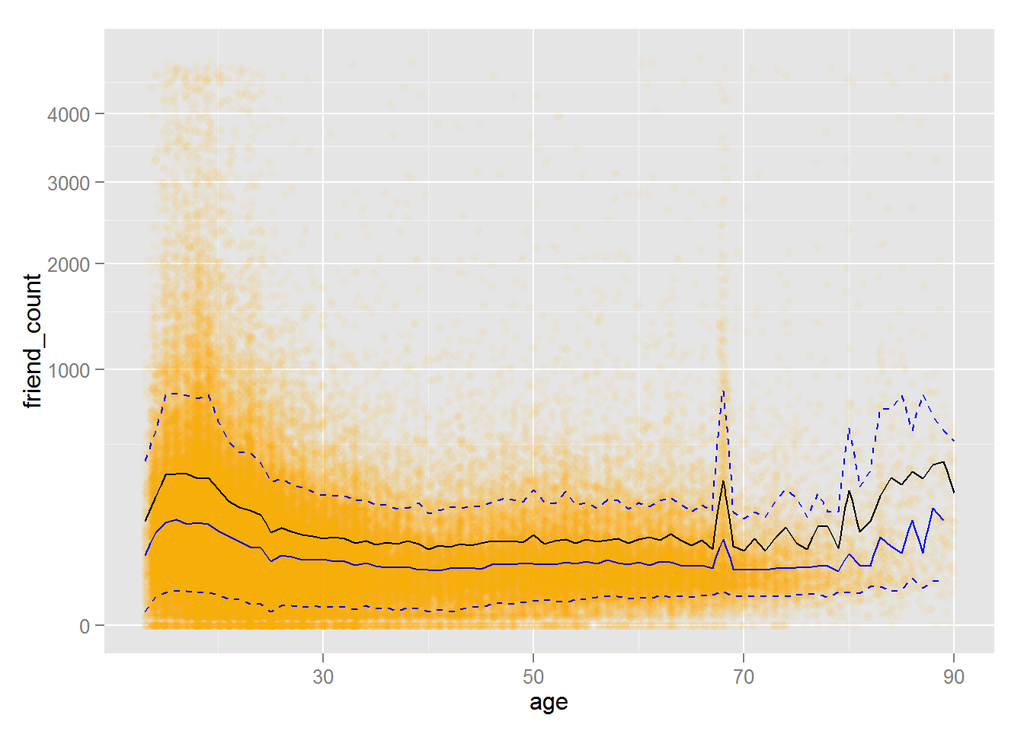

```r
ggplot(pf, aes(x = age, y = friend_count)) +
    geom_point(alpha = 1/20, position = position_jitter(h = 0), color = "orange") +
    xlim(13, 90) +
    coord_trans(y = "sqrt") +
    geom_line(stat = "summary", fun.y = mean) +
    geom_line(stat = "summary", fun.y = quantile, probs = .1, linetype = 2, color = "blue") +
    geom_line(stat = "summary", fun.y = quantile, probs = .5, linetype = 1, color = "blue") +
    geom_line(stat = "summary", fun.y = quantile, probs = .9, linetype = 2, color = "blue")
```

#### What are some of your observations of the plot?

Response:

- the mean is larger than the median for every age ***

### Moira: Histogram Summary and Scatterplot

See the Instructor Notes of this video to download Moira’s paper on perceived audience size and to see the final plot.

Notes:

### Correlation

Notes:

```r
cor.test(pf$age, pf$friend_count)
```

```
##
##  Pearson's product-moment correlation
##
## data:  pf$age and pf$friend_count
## t = -8.6268, df = 99001, p-value < 2.2e-16
## alternative hypothesis: true correlation is not equal to 0
## 95 percent confidence interval:
##  -0.03363072 -0.02118189
## sample estimates:
##         cor
## -0.02740737
```

Look up the documentation for the cor.test function.

What’s the correlation between age and friend count? Round to three decimal places. Response:

### Correlation on Subsets

Notes:

```r
with(subset(pf, age <= 70) ,cor.test(age, friend_count))
```

```
##
##  Pearson's product-moment correlation
##
## data:  age and friend_count
## t = -52.592, df = 91029, p-value < 2.2e-16
## alternative hypothesis: true correlation is not equal to 0
## 95 percent confidence interval:
##  -0.1780220 -0.1654129
## sample estimates:
##        cor
## -0.1717245
```

### Correlation Methods

Notes:

- spearman correlation is more robust to outliers

## Create Scatterplots

Notes:

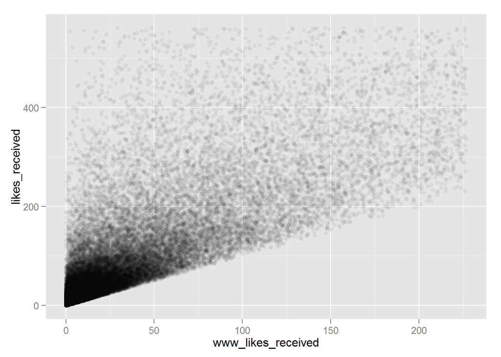

```r
ggplot(pf, aes(x = www_likes_received, y = likes_received)) +
    xlim(0, quantile(pf$www_likes_received, 0.95)) +
    ylim(0, quantile(pf$likes_received, 0.95)) +
    geom_point(alpha = 1/20, position = position_jitter(h = 0))
```

### Strong Correlations

Notes:

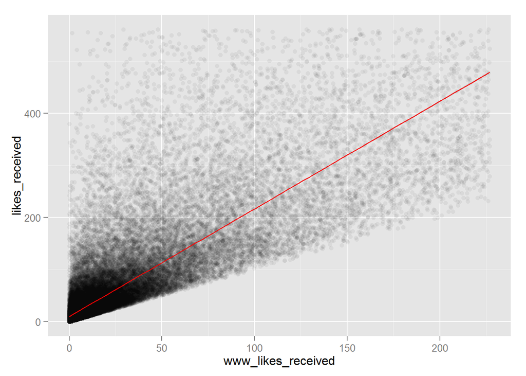

```r
ggplot(pf, aes(x = www_likes_received, y = likes_received)) +
    xlim(0, quantile(pf$www_likes_received, 0.95)) +
    ylim(0, quantile(pf$likes_received, 0.95)) +
    geom_point(alpha = 1/20, position = position_jitter(h = 0)) +
    geom_smooth(method = "lm", color = "red", width = 2)
```

What’s the correlation betwen the two variables? Include the top 5% of values for the variable in the calculation and round to 3 decimal places.

```r
with(pf, cor(www_likes_received, likes_received))
```

```
## [1] 0.9479902
```

Response:

### Moira on Correlation

Notes:

### More Caution with Correlation

Notes:

```r
# install.packages('alr3')
library(alr3)
```

Create your plot!

```r
data(Mitchell)
str(Mitchell)
```

```
## 'data.frame':    204 obs. of  2 variables:
##  $ Month: int  0 1 2 3 4 5 6 7 8 9 ...
##  $ Temp : num  -5.18 -1.65 2.49 10.4 14.99 ...
```

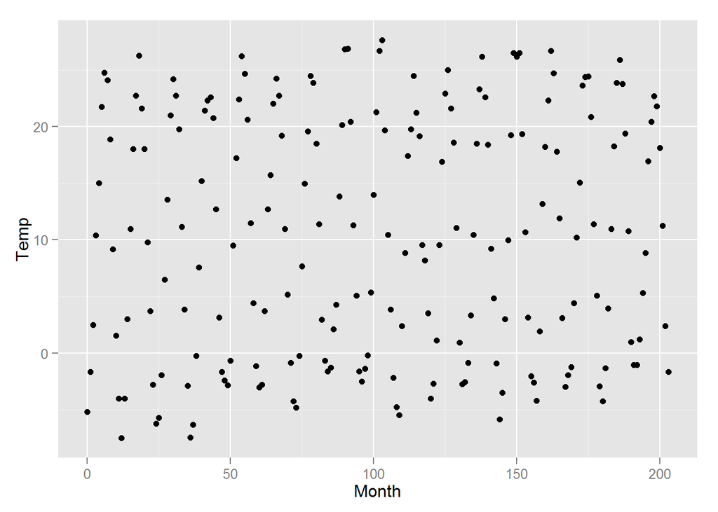

```r
ggplot(Mitchell, aes(x = Month, y = Temp)) +
    geom_point()
```

### Noisy Scatterplots

1. Take a guess for the correlation coefficient for the scatterplot.
2. What is the actual correlation of the two variables? (Round to the thousandths place)

```r
with(Mitchell, cor(Temp, Month))
```

```
## [1] 0.05747063
```

### Making Sense of Data

Notes:

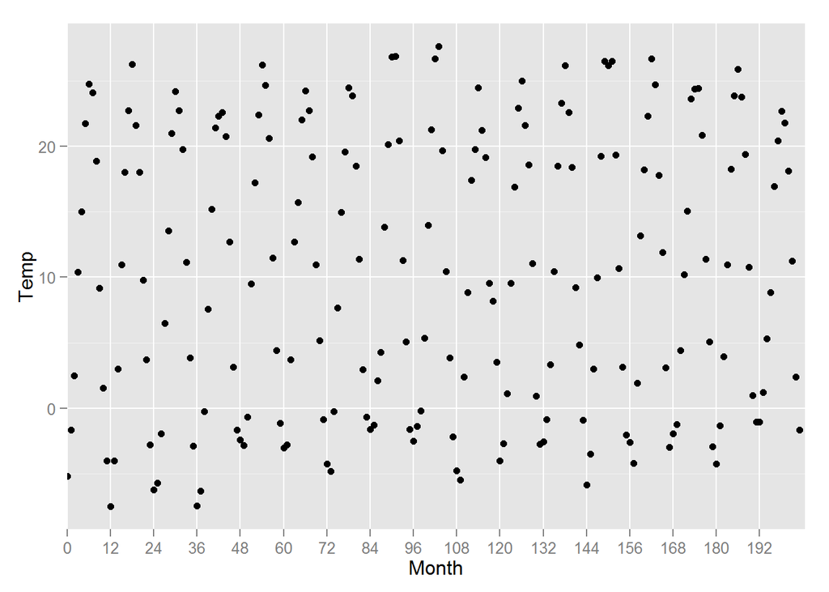

```r
ggplot(Mitchell, aes(x = Month, y = Temp)) +
    geom_point() +
    scale_x_discrete(breaks = seq(0, max(Mitchell$Month), 12))
```

### A New Perspective

What do you notice? Response: There seems to be periodicity in the data.

Watch the solution video and check out the Instructor Notes! Notes:

### Understanding Noise: Age to Age Months

Notes:

```r
pf$age_with_months <- pf$age + (12 - pf$dob_month) / 12
```

### Age with Months Means

Programming Assignment

```r
pf.fc_by_age_months <- pf %>%
    group_by(age_with_months) %>%
    summarise(friend_count_mean = mean(friend_count),
              friend_count_median = median(friend_count) * 1,
              n = n()) %>%
    arrange(age_with_months)
pf.fc_by_age_months
```

```
## Source: local data frame [1,194 x 4]
##
##    age_with_months friend_count_mean friend_count_median   n
## 1         13.16667          46.33333                30.5   6
## 2         13.25000         115.07143                23.5  14
## 3         13.33333         136.20000                44.0  25
## 4         13.41667         164.24242                72.0  33
## 5         13.50000         131.17778                66.0  45
## 6         13.58333         156.81481                64.0  54
## 7         13.66667         130.06522                75.5  46
## 8         13.75000         205.82609               122.0  69
## 9         13.83333         215.67742               111.0  62
## 10        13.91667         162.28462                71.0 130
## ..             ...               ...                 ... ...
```

### Noise in Conditional Means

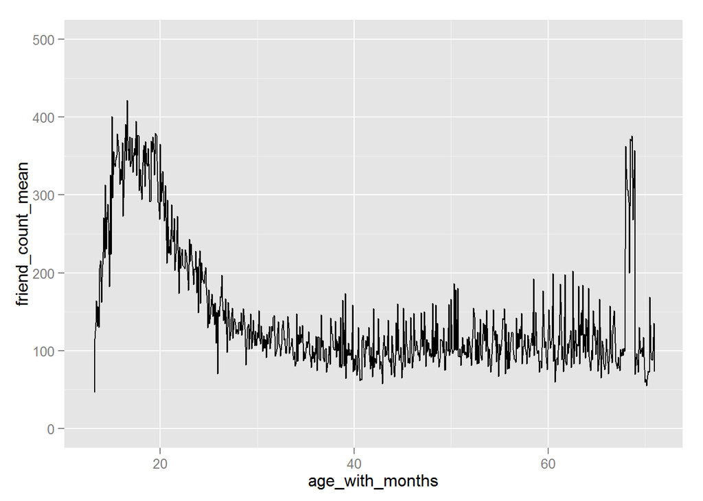

```r
ggplot(pf.fc_by_age_months, aes(x = age_with_months, y = friend_count_mean)) +
    xlim(13, 71) +
    ylim(0, 500) +
    geom_line()
```

### Smoothing Conditional Means

Notes:

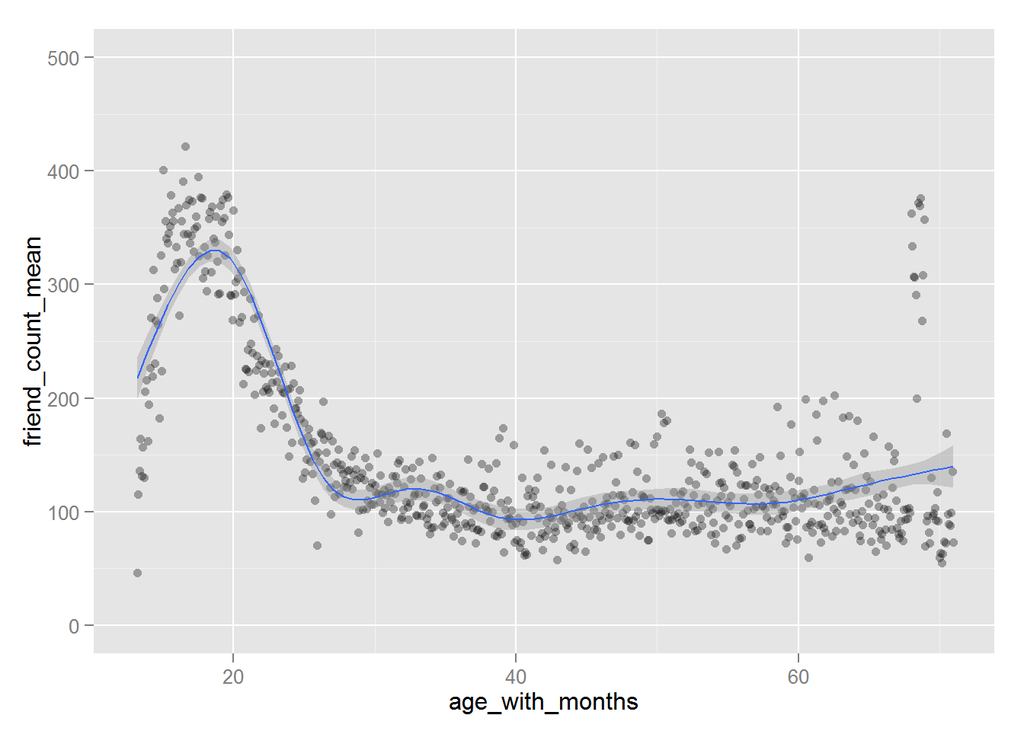

```r
ggplot(pf.fc_by_age_months, aes(x = age_with_months, y = friend_count_mean)) +
    xlim(13, 71) +
    ylim(0, 500) +
    geom_point(alpha = 1/3) +
    geom_smooth()
```

### Which Plot to Choose?

Notes:

- It depends on the level of detail we want

### Analyzing Two Variables

Reflection:

- It is always a good idea to begin with a scatterplot.
- When analyzing two variables models might lose information.
- Correlation is a measure of the linear relationship and ignores things like periodicity.

Click **KnitHTML** to see all of your hard work and to have an html page of this lesson, your answers, and your notes!